# An exemple of reproducible research with `R`

Christophe Pouzat (christophe.pouzat@parisdescartes.fr), Université Paris-Descartes & CNRS

May 16 2017

# The problem

## The Model to check

The model we want to check is:
$$\mathrm{ADU} \sim \mathcal{N}\left(\mathrm{G} \mathrm{F}, \mathrm{G}^2 (\mathrm{F} + \sigma^2_{ro})\right)\, .$$
In Words: $\mathrm{ADU}$ is a *random variable* with a Gaussian distribution whose mean is $\mathrm{G} \mathrm{F}$ and whose variance is $\mathrm{G}^2 (\mathrm{F} + \sigma^2_{ro})$.

$G$ is the gain and $\sigma^2_{ro}$ is the *read-out variance* of the CCD camera.

## The data

Our colleagues from the [Laboratory of Peter Kloppenburg](http://cecad.uni-koeln.de/Prof-Peter-Kloppenburg.82.0.html) used the following protocol (from the *Methods* section of Joucal et al (2010) [Quantitative Estimation of Calcium Dynamics From Ratiometric Measurements: A Direct, Nonratioing Method](http://jn.physiology.org/content/103/2/1130) *Journal of Neurophysiology* **103(2)**: 1130-1144):

*Experimental characterization of a CCD camera*. We performed experiments to characterize the gain and readout noise of an Imago/ SensiCam CCD camera (Till Photonics, Gräfelfing, Germany). Fluorescence measurements were made using a fluorescent plastic slide (Chroma-Gesellschaft, Stuttgart, Germany). Ten exposure times were used, from 10 to 100 ms. For each duration, 100 consecutive measurements were performed with a cycle time of 200 ms. Means and variances were calculated on the 100 measurements for each pixel and then averaged over the 60 x 80 pixels of the camera. The 10 variances were then linearly fitted against the corresponding 10 means.

### Getting the data

I have stored these calibration data in an [HDF5](https://www.hdfgroup.org/hdf5/) file on my website. They can be downloaded from the following address: `http://xtof.disque.math.cnrs.fr/data/CCD_calibration.hdf5`. Using `RMarkdown` we have 2 possibilities to download them, either from the [`Bash shell`](https://en.wikibooks.org/wiki/Bash_Shell_Scripting) using program [`wget`](https://www.gnu.org/software/wget/) as follows:

```bash
wget http://xtof.disque.math.cnrs.fr/data/CCD_calibration.hdf5
```

or directly from `R` with function `download.file` as follows:

```r
download.file(url="http://xtof.disque.math.cnrs.fr/data/CCD_calibration.hdf5",
              destfile="CCD_calibration.hdf5")
```

Either way, once this is done we can check in `R` with `list.files` that the file is indeed on our hard-drive:

```r
list.files()[grep("*.hdf5$",list.files())]
```

```
## [1] "CCD_calibration.hdf5"
```

### Loading the data into `R`

There are two libraries for dealing with `HDF5` files in `R`:

- [`rhdf5`](http://www.bioconductor.org/packages/release/bioc/html/rhdf5.html)
- [`h5`](https://cran.r-project.org/package=h5)

The first is on [Bioconductor](http://www.bioconductor.org/) and is installed as follows:

```r
source("https://bioconductor.org/biocLite.R")
biocLite("rhdf5")
```

The second in on the `CRAN` and is intalled with the “usual proccedure”:

```r
install.packages("h5")
```

We are going to use `rhdf5` here and we start by loading it in our `searchpaths`:

```r
library(rhdf5)
```

We can then see its overall structure with:

```r
h5ls("CCD_calibration.hdf5")
```

```
##     group  name       otype  dclass   dim
## 0       / 100ms   H5I_GROUP
## 1  /100ms stack H5I_DATASET INTEGER  x 60
## 2  /100ms  time H5I_DATASET   FLOAT   100
## 3       /  10ms   H5I_GROUP
## 4   /10ms stack H5I_DATASET INTEGER  x 60
## 5   /10ms  time H5I_DATASET   FLOAT   100
## 6       /  20ms   H5I_GROUP
## 7   /20ms stack H5I_DATASET INTEGER  x 60
## 8   /20ms  time H5I_DATASET   FLOAT   100
## 9       /  30ms   H5I_GROUP
## 10  /30ms stack H5I_DATASET INTEGER  x 60
## 11  /30ms  time H5I_DATASET   FLOAT   100
## 12      /  40ms   H5I_GROUP
## 13  /40ms stack H5I_DATASET INTEGER  x 60
```

[output cut: 16 more lines]

We see that our file contains 10 `Groups` named: `10ms`, `20ms`,…, `100ms`. They correspond to the 10 different exposure times. Each `Group` is composed of 2 `Datasets`, one named `stack` (it contains the stack of images) and one named `time` (it contains the times at which the individual images of the stack were taken). We can read the 10 stacks into a list of stacks as follows:

```r
stacks = lapply((1:10)*10,function(i) h5read("CCD_calibration.hdf5",paste0("/",i,"ms/stack")))
names(stacks) = paste0((1:10)*10,"ms")
str(stacks)
```

```
## List of 10
##  $ 10ms : int [1:100, 1:80, 1:60] 383 371 387 394 372 380 382 382 366 368 ...
##  $ 20ms : int [1:100, 1:80, 1:60] 765 733 757 723 733 741 731 738 760 730 ...
##  $ 30ms : int [1:100, 1:80, 1:60] 1115 1115 1120 1079 1106 1114 1091 1120 1097 1119 ...
##  $ 40ms : int [1:100, 1:80, 1:60] 1460 1457 1439 1473 1470 1460 1468 1485 1460 1488 ...
##  $ 50ms : int [1:100, 1:80, 1:60] 1826 1803 1810 1831 1842 1820 1812 1810 1839 1829 ...
##  $ 60ms : int [1:100, 1:80, 1:60] 2178 2146 2190 2205 2215 2172 2185 2209 2213 2174 ...
##  $ 70ms : int [1:100, 1:80, 1:60] 2553 2513 2530 2542 2535 2522 2525 2520 2522 2534 ...
##  $ 80ms : int [1:100, 1:80, 1:60] 2921 2865 2911 2920 2917 2897 2880 2885 2877 2917 ...
##  $ 90ms : int [1:100, 1:80, 1:60] 3260 3299 3258 3284 3239 3276 3243 3245 3282 3288 ...
##  $ 100ms: int [1:100, 1:80, 1:60] 3635 3616 3614 3606 3616 3643 3610 3653 3607 3616 ...
```

We can make a graph using a gray scale of the first image at the shortest exposure time as follows:

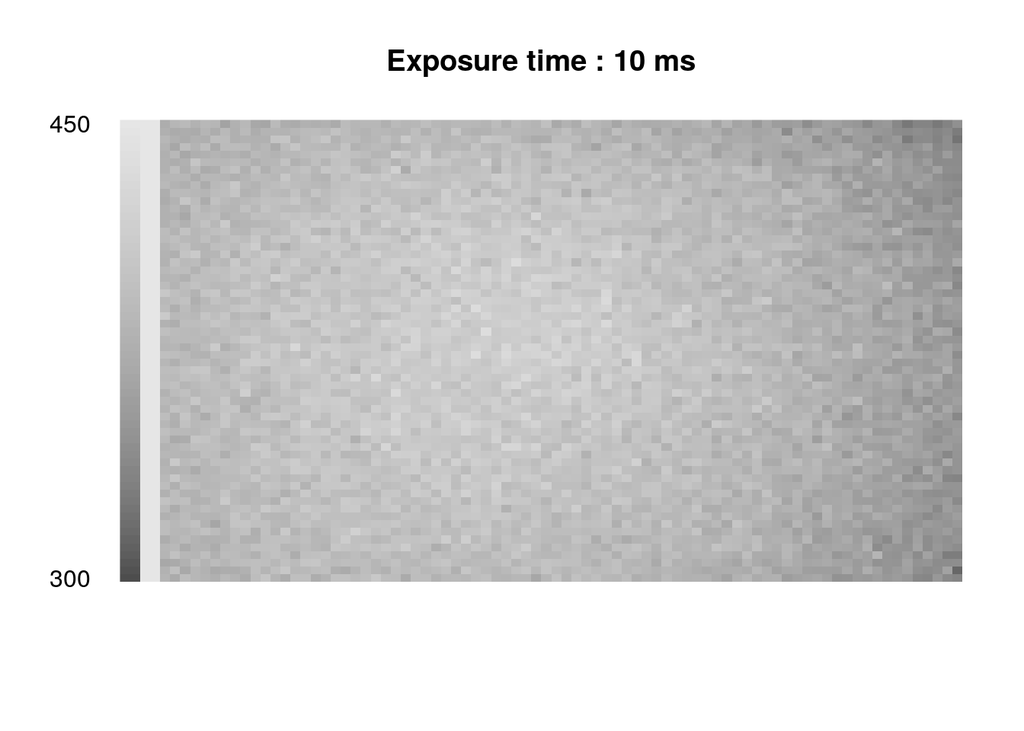

```r
chipImage = rbind(matrix(seq(300,450,len=60),nrow=2,ncol=60,byrow=TRUE),
                  matrix(450,nrow=2,ncol=60),
                  stacks[["10ms"]][1,,])
image(chipImage,
      col=gray.colors(256),
      axes=FALSE,
      xlab="",
      ylab="",
      main="Exposure time : 10 ms")
axis(2,at=c(0,1),
     labels=c("300","450"),
     lty=0,las=1)
mtext("ADU      ",side=2,las=1,cex=3)
```

# Model predictions

How can we test $\mathrm{ADU} \sim \mathrm{G} \, \mathrm{F} + \sqrt{\mathrm{G}^2 \, (\mathrm{F}+\sigma_{ro}^2)} \, \epsilon$ ? By setting differnt values for $\mathrm{F}$, but how can we do that?

Let’s consider a pixel of our CCD “looking” at a fixed volume of fluorescent material. We have two ways of modifying $\mathrm{F}$:

- Change the intensity $i_{e}$ of the light source exciting the fluorophore.
- Change the exposure time $\tau$.

We can indeed write our $\mathrm{F}$ as:
$$\mathrm{F} = \phi v c i_{e} \tau \, ,$$
where

- $v$ is the fluorophore’s volume “seen” by a given pixel,
- $c$ is the fluorophore’s concentration,
- $\phi$ is the [quantum yield](http://en.wikipedia.org/wiki/Quantum_yield).

We introduce a *random variable* (rv) $\mathrm{ADU}_{i,j}$ for each pixel because it is very difficult (impossible) to have a uniform intensity ($i_e$) and a uniform volume ($v$) and a uniform quantum yield ($\phi$). We have therefore for each pixel:
$$\mathrm{ADU}_{i,j} \sim \mathrm{G} \, p_{i,j} \tau + \sqrt{\mathrm{G}^2 \, (p_{i,j} \tau+\sigma_{ro}^2)} \, \epsilon_{i,j}\; ,$$
where $p_{i,j} = c \phi_{i,j} v_{i,j} i_{e,i,j}$.

# Empirical test

For each pixel at each exposure time we want to get the mean count and its variance:

```r
ADU.m <- as.vector(
    sapply(1:length(stacks),
           function(idx)
           apply(stacks[[idx]],
                 c(2,3),mean)))
ADU.v <- as.vector(
    sapply(1:length(stacks),
           function(idx)
           apply(stacks[[idx]],
                 c(2,3),var)))
```

We plot the variance as a function of the mean:

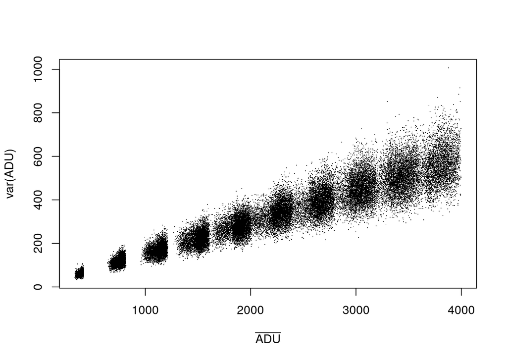

```r
plot(ADU.m,
     ADU.v,
     pch=".",
     xlab=expression(bar(ADU)),
     ylab="var(ADU)"
     )
```

We do see the expected linear relation: $\mathrm{Var}[\mathrm{ADU}] = \mathrm{G} \mathrm{E}[\mathrm{ADU}] + \mathrm{G}^2 \sigma_{ro}^2$.

The [heteroscedasticity](http://en.wikipedia.org/wiki/Heteroscedasticity) (inhomogeneous variance) visible on the graph is also expected since the variance of a variance for an IID sample of size $n$ from a normal distribution with mean $\mu$ and variance $\sigma^2$ is:
$$\mathrm{Var}[S^2] = \frac{2\sigma^4}{(n-1)} \; .$$

- This means than when we do our linear fit we should use weights.
- A software package like `R` allows us to do that by giving a vector whose elements are proportional to inverse of the variance.

This is done with:

```r
varVSmean = lm(ADU.v ~ ADU.m, weights = 99/2/ADU.v^2)
```

Leading to the following coefficients:

```r
round(coefficients(varVSmean),digits=3)
```

```
## (Intercept)       ADU.m
##       5.611       0.140
```

This means that our estimate $\widehat{\mathrm{G}}$ for $\mathrm{G}$ is:

```r
(G_hat = coefficients(varVSmean)[2])
```

```
##     ADU.m
## 0.1398383
```

and our estimate $\widehat{\sigma}^2_{ro}$ for $\sigma^2_{ro}$ is:

```r
(S2_hat = coefficients(varVSmean)[1]/G_hat^2)
```

```
## (Intercept)
##     286.959
```

We should **never** stop here but at least plot the *normalized residuals* as a function of the fitted value:

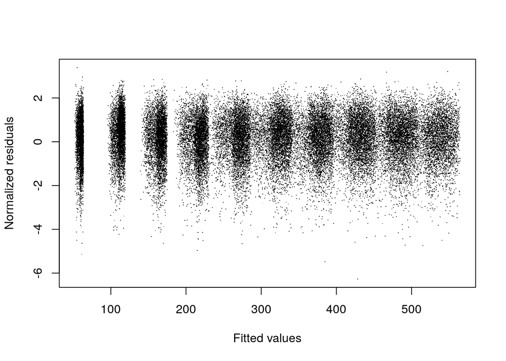

```r
plot(varVSmean$fitted.values,varVSmean$residuals*sqrt(99/2)/ADU.v,pch=".",
     xlab="Fitted values",ylab="Normalized residuals")
```

I have just scratched the surface of what a proper analysis of this data set should be. If you want to learn more, check my ENP course: https://zenodo.org/record/18691.